# HELPmiss (Data Verbs) Activity

Mia Iceland

## Set Up:

| count |
| --- |
| 470 |

| sum(e2b, na.rm = TRUE) |
| --- |
| 549 |

2. total number of times in the past 6 months entered a detox program (measured at baseline) for all the people in `HELPmiss`.

| mean(daysanysub, na.rm = TRUE) |
| --- |
| 75.13095 |

3. mean time (in days) to first use of any substance post-detox for all the people in `HELPmiss`

```r
HELPmiss %>%
  group_by(sex) %>%
  summarise(count= n())
```

| sex | count |
| --- | --- |
| male | 359 |
| female | 111 |

```r
HELPmiss %>%
  group_by(sex) %>%
  summarise(sum(e2b, na.rm=TRUE))
```

| sex | sum(e2b, na.rm = TRUE) |
| --- | --- |
| male | 457 |
| female | 92 |

```r
HELPmiss %>%
  group_by(sex) %>%
  summarise(mean(daysanysub, na.rm=TRUE))
```

| sex | mean(daysanysub, na.rm = TRUE) |
| --- | --- |
| male | 72.60513 |
| female | 83.77193 |

```r
NA
```

*Repeat task 2 above, but add code chunks to calculate result group-by-group according to each prompt (i.e. each prompt should have three statements for each of the three prompts in task 2). Be sure to show all R code and write a sentence or two about what you observe in the results. Remember, you can add multiple statistics inside `summary`.*

- males versus females
  - I noticed that there are more male participants in this study than females. Also, more males than females had previously entered a detox program before 6 months before this trial started. Finally, men are faster to start reusing a substance post-detox.
- homeless or not
  - More people in this study have a home than those that are homeless. More homeless people than people with homes had previously entered a detox program before 6 months before this trial started. Lastly, homeless people are faster to start reusing a substance post-detox.
- substance
  - The most abused substance in this trial is alcohol. Alcohol abusers are the largest group of people who had previously entered a detox program before 6 months before this trial started. Finally, people who use heroin are faster to start reusing their “substance of choice” post-detox.
- break down the homeless versus housed further, by sex
  - The greatest number of people in this study are housed males. Also, homeless males are the largest group of people who had previously entered a detox program before 6 months before this trial started. Lastly, homeless males are faster to start reusing their abused substance post-detox.
- homeless versus housed broken down by substance
  - The greatest number of people in this study are homeless and abuse alcohol. Homeless alcohol abusers are the largest group of people who had previously entered a detox program before 6 months before this trial started. Housed heroin users are faster to start reusing heroin post-detox.

```r
HELPmiss %>%
  group_by(homeless) %>%
  summarise(count= n())
```

| homeless | count |
| --- | --- |
| housed | 251 |
| homeless | 219 |

```r
HELPmiss %>%
  group_by(homeless) %>%
  summarise(sum(e2b, na.rm=TRUE))
```

| homeless | sum(e2b, na.rm = TRUE) |
| --- | --- |
| housed | 160 |
| homeless | 389 |

```r
HELPmiss %>%
  group_by(homeless) %>%
  summarise(mean(daysanysub, na.rm=TRUE))
```

| homeless | mean(daysanysub, na.rm = TRUE) |
| --- | --- |
| housed | 77.10078 |
| homeless | 73.06504 |

```r
NA
```

```r
HELPmiss %>%
  group_by(substance) %>%
  summarise(count= n())
```

| substance | count |
| --- | --- |
| alcohol | 185 |
| cocaine | 156 |
| heroin | 128 |
| missing | 1 |

```r
HELPmiss %>%
  group_by(substance) %>%
  summarise(sum(e2b, na.rm=TRUE))
```

| substance | sum(e2b, na.rm = TRUE) |
| --- | --- |
| alcohol | 242 |
| cocaine | 98 |
| heroin | 208 |
| missing | 1 |

```r
HELPmiss %>%
  group_by(substance) %>%
  summarise(mean(daysanysub, na.rm=TRUE))
```

| substance | mean(daysanysub, na.rm = TRUE) |
| --- | --- |
| alcohol | 78.49495 |
| cocaine | 86.67033 |
| heroin | 52.82258 |
| missing | NaN |

```r
NA
```

```r
HELPmiss %>%
  group_by(sex, homeless) %>%
  summarise(count= n())
```

| sex | homeless | count |
| --- | --- | --- |
| male | housed | 182 |
| male | homeless | 177 |
| female | housed | 69 |
| female | homeless | 42 |

```r
HELPmiss %>%
  group_by(sex, homeless) %>%
  summarise(sum(e2b, na.rm=TRUE))
```

| sex | homeless | sum(e2b, na.rm = TRUE) |
| --- | --- | --- |
| male | housed | 110 |
| male | homeless | 347 |
| female | housed | 50 |
| female | homeless | 42 |

```r
HELPmiss %>%
  group_by(sex, homeless) %>%
  summarise(mean(daysanysub, na.rm=TRUE))
```

| sex | homeless | mean(daysanysub, na.rm = TRUE) |
| --- | --- | --- |
| male | housed | 74.30851 |
| male | homeless | 71.01980 |
| female | housed | 84.60000 |
| female | homeless | 82.45455 |

```r
HELPmiss %>%
  group_by(homeless, substance) %>%
  summarise(count= n())
```

| homeless | substance | count |
| --- | --- | --- |
| housed | alcohol | 76 |
| housed | cocaine | 96 |
| housed | heroin | 79 |
| homeless | alcohol | 109 |
| homeless | cocaine | 60 |
| homeless | heroin | 49 |
| homeless | missing | 1 |

```r
HELPmiss %>%
  group_by(homeless, substance) %>%
  summarise(sum(e2b, na.rm=TRUE))
```

| homeless | substance | sum(e2b, na.rm = TRUE) |
| --- | --- | --- |
| housed | alcohol | 34 |
| housed | cocaine | 37 |
| housed | heroin | 89 |
| homeless | alcohol | 208 |
| homeless | cocaine | 61 |
| homeless | heroin | 119 |
| homeless | missing | 1 |

```r
HELPmiss %>%
  group_by(homeless, substance) %>%
  summarise(mean(daysanysub, na.rm=TRUE))
```

| homeless | substance | mean(daysanysub, na.rm = TRUE) |
| --- | --- | --- |
| housed | alcohol | 104.79487 |
| housed | cocaine | 81.05556 |
| housed | heroin | 41.16667 |
| homeless | alcohol | 61.40000 |
| homeless | cocaine | 94.86486 |
| homeless | heroin | 68.96154 |
| homeless | missing | NaN |

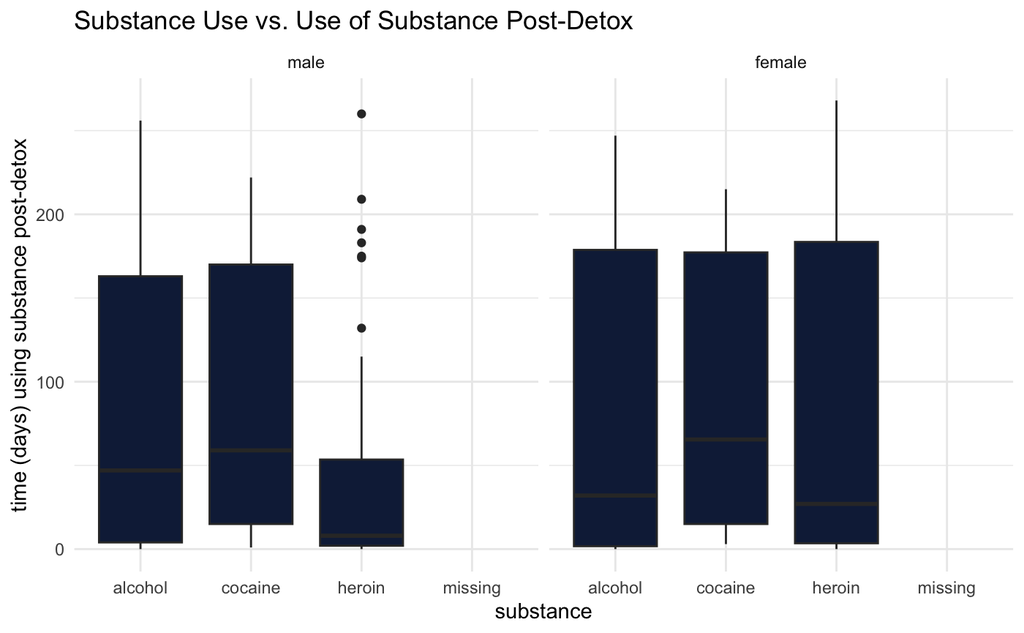

## Task 4: Data Visualization & Observations

*Include one or more interesting plots from this data set involving at least 3 variables per plot. Write a few sentences to explain the story that your plot tells about these data. You can expand on the relationships that you studied in Task 2, or you can explore a different group of variables in `HELPmiss` that show something interesting. Remember to use the interactive commands in the console, generate the R commands that will reproduce your plot, and then paste the R commands into an R chunk in the RMarkdown file.*

*Remember, you can use* `esquisser` *or* `mplot` *in your console. But only include the ggplot code in this Rmd document.*

```r
ggplot(HELPmiss) +
  aes(x = substance, y = daysanysub) +
  geom_boxplot(fill = "#112446") +
  labs(
    y = "time (days) using substance post-detox",
    title = "Substance Use vs. Use of Substance Post-Detox"
  ) +
  theme_minimal() +
  facet_wrap(vars(sex))
```

My graph breaks down how long takes for each sex and substance to relapse post-detox. Through my graph, I found that, on average, it takes the shortest amount of time for both sexes to reuse heroin and the longest time to reuse cocaine. The graph also shows, on average, that other than alcohol, it takes a shorter amount of time for men to relapse their cocaine and heroin addiction. Women, however, undergo alcohol abuse quicker post-detox than men.